# A Gentle Introduction

Getting to know R

2020 November

# 1 An overview

## 1.1 What is R

R is an open source programming language that is extremely versatile and rapidly becoming the top choice for data analysis tasks both in academia and in the industry. It is different from ‘point and click’ software (such as SPSS) since you need to write code to tell R what you want it to do. This means a steep learning curve but even on the short run will allow to produce code that is custom made to your specific problem and can be reproduced reliably by you or others.

## 1.2 Why R?

- One of the most used statistical tools in academia and in industry
- It is open source, which means that the functions are not black boxes; when in doubt you can check what happens under the hood.
- Because it is open source, it is at the cutting-edge of implementing new methods
- The R developer and user community is great in numbers and in resources. If you have a problem, chances are there is a package for that or an online discussion on how to solve it.
- Reproducible research, which means that your code will produce the exact same output, making it easier to replicate your results or verify your (or others’) methods.
- Statistical programming is a great transferable skill to have
- Free of charge

**Evidence 1:**

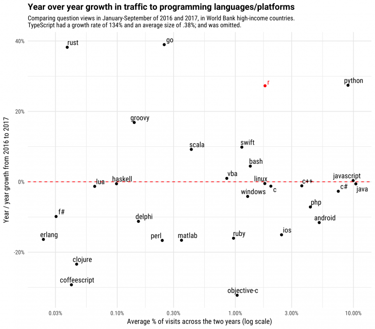

**Evidence 2:**

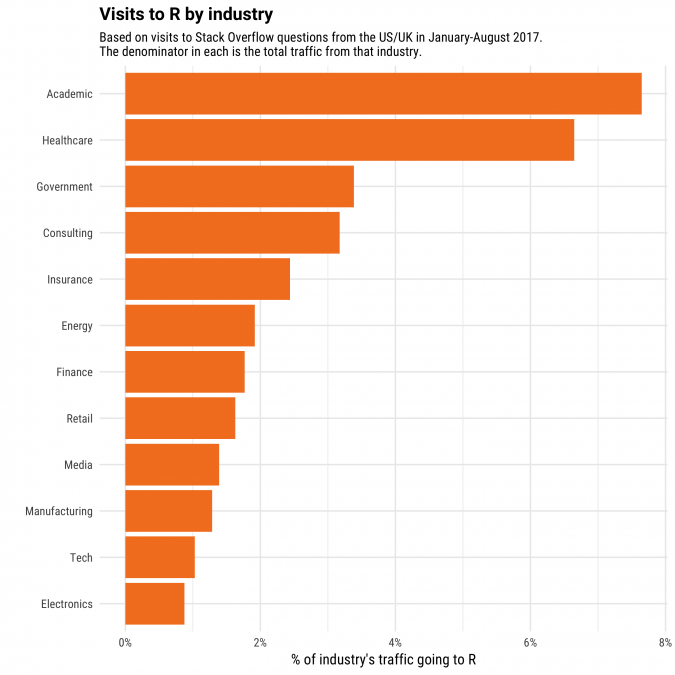

*Source: https://stackoverflow.blog/2017/10/10/impressive-growth-r/*

# 2 Setting up R and RStudio

> Supplimentary resources: [RStudio IDE Cheat Sheet](https://www.rstudio.com/wp-content/uploads/2016/01/rstudio-IDE-cheatsheet.pdf)

R comes with a pretty spartan GUI so we will work with the RStudio IDE (integrated development environment).

The workflow with RStudio consists of using:

1. Scripts for writing code (you should avoid working directly to the console!)
2. Projects, so your work is self-contained.
3. Some miscalleneus setting that *really* helps

Some tips for using RStudio:

- Under `Tools -> Global Options` you can change the following:
  - `Code -> Editing -> Soft wrap R source files` If you check this, the lines in your script file do not run “out of the window”.
  - `Appearance`: You can select your colour scheme here. If you stare at the screen for a long time, white text against a darker background might be less hard on the eyes.
  - `Pane layout`: Here you can select how the window space in R studio is arranged. It might be useful to keep your source file on the one side and the console on the other side and not on top of each other. (see pic below)
- A few essential keyboard short-cuts (for Windows):
  - Control+Enter: run the code on the current line
  - Control+Alt+B: run the code from the beginning to the current line.
  - Control+Alt+E: run the code from the current line to the end of the source file.
  - Control+D: delete the current line.
  - Alt+Shift+Up/Down: Copy the current line above or below the line.
  - Alt+Control+Up/Down: Copy the current line above or below the line.
  - You can see the full list of keyboard short-cuts in RStudio, if you press **Alt+Shift+K**

[figure not shown]

## 2.1 Using Projects

Using Projcets with RStudio will simplify your workflow. Essentially, all your project related files are collected in your selected folder so you don’t need to specify a working directory. Your project will be able to run as long as you copy the entire folder.

How to set one up: `File -> New Project` then choose a directory where you want to have your R scripts, data and history files. You should also disable the **“Restore most recently opened project at startup”** and **“Restore .RData ino workspace at startup”**, and also set **“Save workspace to .RData on exit”** to **Never** in `Tools -> Global Options -> General`

For more help and materials on using projects, see [RStudio’s own resource page](https://support.rstudio.com/hc/en-us/articles/200526207-Using-Projects) or a [well argued reasoning from Jenny Brian](https://www.tidyverse.org/articles/2017/12/workflow-vs-script/)

[figure not shown]

### 2.1.1 Before we move on

Let’s talk about keeping your R and other projects safe from tornadoes, toddlers, toasters or T-rexes. Ideally, your work lives on your (1) hard drive *AND* a (2) back-up hard drive (preferably an SSD) *AND* a (3) cloud service (such as Dropbox, Google Drive, MS OneDrive).

I would recommend Dropbox as it seems to be the most robust out of these three. It also has file version history, so even if you accidentally delete something can get it back. A big plus for Dropbox and R projects is that they play nice with each other, as opposed to Google Drive and R projects which will annoy you into oblivion with error messages because of writing and reading conflicts.

> **General tips:**
> - Check the [R coding style guide](http://style.tidyverse.org/index.html)
> - Comment your codes heavily (with the `#`) because now seemingly straightforward code will not be so in the future
> - Use sensible file names (e.g.: `01_data_cleaning.R`)
> - R is case sensitive, so use lowercase file and variable names. Separate words with underscore `_` (e.g.: `ols_reg_1`) (or you can do the camelCase thing, but be consistent)

## 2.2 Getting help and citing R and packages

It is OK to get stuck in R and look for help. Don’t worry if don’t remember a function’s name or arguments by heart, as with everything the more you write R, the more you can recall from memory. Programming (R included) requires great Google search skills (or DuckDuckGo, if you are not keen on Google) but just like drawing, math or sword forging for the Japanese emperor it requires a great amount of practice and not some innate mystical ability that only 5% of the living population posess. My advice: find your pet projects, find joy in R, do not give up and use Google and StackOverflow without any hesitation.

Some effective ways to seek help with R related problems:

- Within R, you can just type `?function name` and you will be shown the function help. This is often not that informative.
- Google “R” followed by the name of the package and/or a very short description of the problem. Like this: **“R ggplot bar chart”**
- Google “R” followed by the error message (or part of it) that R gives you. Don not forget to double check for typos, missed commas, brackets or some other trivial problem.
- Most of the case one of the first hits will be a topic on [StackOverflow](https://stackoverflow.com/). You can use it to ask your own questions, BUT check if it is not a duplicate because there is a good chance that some else already encountered the same problem that you are searching for.

Since R is an open source project it is a common courtesy to cite R and the packages you use, as people (often in academia) put many hours into developing tools and it is in our common interest to give some public recognition to these efforts and contributions. To see how to cite R or you can just type the following:

```r
citation()
```

```
#>
#>
#>   R Core Team (2020). R: A language and environment for statistical
#>   computing. R Foundation for Statistical Computing, Vienna, Austria.
#>   URL https://www.R-project.org/.
#>
#> A BibTeX entry for LaTeX users is
#>
#>   @Manual{,
#>     title = {R: A Language and Environment for Statistical Computing},
#>     author = {{R Core Team}},
#>     organization = {R Foundation for Statistical Computing},
#>     address = {Vienna, Austria},
#>     year = {2020},
#>     url = {https://www.R-project.org/},
#>   }
#>
#> We have invested a lot of time and effort in creating R, please cite it
#> when using it for data analysis. See also 'citation("pkgname")' for
#> citing R packages.
```

You can cite a specific package with the following:

```r
citation("quanteda")
```

```
#>
#> Benoit K, Watanabe K, Wang H, Nulty P, Obeng A, Müller S, Matsuo A
#> (2018). "quanteda: An R package for the quantitative analysis of
#> textual data." _Journal of Open Source Software_, *3*(30), 774. doi:
#> 10.21105/joss.00774 (URL: https://doi.org/10.21105/joss.00774), <URL:
#> https://quanteda.io>.
#>
#> A BibTeX entry for LaTeX users is
#>
#>   @Article{,
#>     title = {quanteda: An R package for the quantitative analysis of textual data},
#>     journal = {Journal of Open Source Software},
#>     author = {Kenneth Benoit and Kohei Watanabe and Haiyan Wang and Paul Nulty and Adam Obeng and Stefan Müller and Akitaka Matsuo},
#>     doi = {10.21105/joss.00774},
#>     url = {https://quanteda.io},
#>     volume = {3},
#>     number = {30},
#>     pages = {774},
#>     year = {2018},
#>   }
```

# 3 First steps - Basic operations

> **Main packages used:** `base R`  
> **Main functions covered:** `help`, `c()`, `typeof()`, `lenght()`, `sum()`, `data.frame()`, `matrix()`, `list()`, `[`, `[[`  
> **Supplementary resources:** [Base R Cheat Sheet](https://www.rstudio.com/wp-content/uploads/2016/05/base-r.pdf)

To get started:

- **Create a new project for the course**
- **Start a new R script** by `Ctrl + Shift + N` (or from the top menus).
- **Don’t forget to save** the script to your project folder (`Ctrl + s`)!

You can copy and paste code from this html document to your script and run it, but I recommend that you type everything as it allows for deeper learning experience. If you get stuck you can always check this document. Don’t forget to **comment your code** with `#` (hashtag). Anything in the given line after `#` will not be taken into consideration when the code runs.

## 3.1 Getting started

We can make R carry out basic calculations with the usual symbols: `+ - / *`. You can run the current line (don’t need to select the code) with the `Ctrl + Enter` shortcut.

```r
16+80
```

```
#> [1] 96
```

In addition to carry out numerical operations, you can ask R to check if certain logical conditions are met, such as a value is greater or less or equal to another. It is essentially asking R the question of “is this value greater than that value?” to which we will receive an output of `FALSE` or `TRUE`.

```r
5 > 4 # greater than
```

```
#> [1] TRUE
```

```r
6 < 8
```

```
#> [1] TRUE
```

```r
7 == 7 # equal with
```

```
#> [1] TRUE
```

```r
10 >= 10 # greater or equal than
```

```
#> [1] TRUE
```

```r
42 != 42 # not equal to
```

```
#> [1] FALSE
```

The conditions that you can use in R:

- `a == b` Are equal
- `a != b` Not equal
- `a > b` Greater than
- `a < b` Less than
- `a >= b` Greater than or equal to
- `a <= b` Less than or equal to
- `!x` Not x
- `x | y` x OR y
- `x & y` x AND y
- `is.na(a)` Is missing
- `is.null(a)` Is null

## 3.2 Functions

Functions do the heavy lifting in R. They have the format below:

```r
function(argument1 = value1, argument2 = value2, ...)
```

For example check the following code for computing a square root of 7 by hand and by using a built in `sqrt()` function of R.

```r
# artisanal approach
7^0.5
```

```
#> [1] 2.645751
```

```r
# built in function
sqrt(7)
```

```
#> [1] 2.645751
```

R comes with a variety of math functions if needed. Some examples are below. For the `log()` example, you can see that the first computes the natural logarithm. If you have something else in mind, you can specify it with the `base =` argument.

```r
log(10)
```

```
#> [1] 2.302585
```

```r
# you can specify the base if you want
log(10, base = 10)
```

```
#> [1] 1
```

```r
# if you need to round, you can use the `round()` function and nest the other function in it. E.g.:
round(sin(5), 2)
```

```
#> [1] -0.96
```

## 3.3 Data types, variables and data structures

R let’s you save data by storing it in an object (it’s just a fancy name for stored data basically). You can do it with an assign operator: `<-` (**shortcut: `Left Alt + -`**). The `=` sign also works but it is R coding practice to use `<-` to assign values to objects and use `=` within functions. Using the shortcut helps!

Let’s create two objects, where we store the results of some calculations.

```r
a <- 16+80

b <- 4+4/2
```

Objects are essential part of the R workflow. You can see your current objects in the righ pane named ‘Environment’.

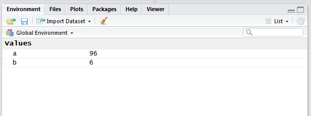

You can check (evaluate) your object by running it’s name. Writing the name of your object is equivalent to printing it to your console.

```r
a
```

```
#> [1] 96
```

```r
print(b)
```

```
#> [1] 6
```

More importantly, we can perform all sorts of operations on our objects which will be the foundation of our workflow later on. This mean that we can have multiple datasets and objects containing all sorts of information (regression outputs, plots, etc.) in the memory.

```r
a/2
```

```
#> [1] 48
```

```r
a*b
```

```
#> [1] 576
```

### 3.3.1 Data frames

```r
df
```

```
#>       country  pop     continent
#> 1    Thailand 68.7          Asia
#> 2      Norway  5.2        Europe
#> 3 North Korea 24.0          Asia
#> 4      Canada 47.8 North America
#> 5    Slovenia  2.0        Europe
#> 6      France 63.6        Europe
#> 7   Venezuela 31.6 South America
```

To understand how each of these types works and how a data frame is constructed we will have to have a more in-depth look at each one. In R parlance, each column is a vector of a given data type.

### 3.3.2 Vectors

You can also combine values into a vector. To do this, we use the `c()` function. Below we will create numeric vectors with lenght of four. When you perform operations with vectors keep in mind that R matches the first element of the first vector to the first element of the second vector (called *element-wise execution*). This will result in a new vector with the same lenght as the originals. You can specify each element of the vector or give a range (e.g.: `c(1:4)`)

```r
c(5, 10, 15, 20)
```

```
#> [1]  5 10 15 20
```

```r
# operations with vectors
c(1:4) + c(10,20,30,40)
```

```
#> [1] 11 22 33 44
```

> QUICK EXCERCISE: check what happens if you try to do operations on numerical vectors of different size!

These vectors can have six types: *doubles*, *integers*, *characters*, *logicals*, *complex*, and *raw*. To check if we are indeed dealing with a vector, we can perform the `is.type` question, as below. We can also check its lenght, just in case. If you are not sure about the type you can skip the trial and error with the `typeof()` function. (we’ll skip complex and raw, as they are so niche that you can just check in case you ever need those)

If you want to refer to a specific value in a vector, you must use square brackets after the name of the object: `[` and `[[`. The brackets contain the sequence number of the value you want to refer to. Such indexing can also be used to replace values in objects. **BEWARE** that R happily overwrites your objects without any warning or double checks and there is no undo button! It is best to create new objects if you plan to further tinker with them.

```r
num <- c(5, 10, 15, 20)

num[3]
```

```
#> [1] 15
```

Assigning a new value to the n-th element of our vector works with combining the assignment operator (`<-`) and the `[` indexing we just learned.

```r
num[3] <- 42

num
```

```
#> [1]  5 10 42 20
```

#### 3.3.2.1 Numerical

```r
num <- c(5, 10, 15, 20)

is.vector(num)
```

```
#> [1] TRUE
```

```r
length(num)
```

```
#> [1] 4
```

```r
typeof(num)
```

```
#> [1] "double"
```

R functions use the name “double” and “numerics” interchangeably (and so will I during the course). (doubles comes from computer science and refers to the number of bytes it takes to store a number) Numerics can be positive, negative, have digits or not, they are regular numbers. If you insist on having an integer vector you can specify it by adding an `L` after the numeric value. In most of the cases you will use numerics instead of integers and R defaults to numerics as well if you do not specify your needs.

```r
int <- c(4L, 7L, 18L)

typeof(int)
```

```
#> [1] "integer"
```

```r
is.integer(int)
```

```
#> [1] TRUE
```

#### 3.3.2.2 Character

For characters, you have to wrap the values between " " (or ’ ’) for R to recognize it as such.

```r
# a vector with character (string) values, with a length of 3 and 1
text1 <- c("Han", "shot", "first")

text2 <- c("Hello world")

typeof(text1)
```

```
#> [1] "character"
```

```r
length(text1)
```

```
#> [1] 3
```

```r
length(text2)
```

```
#> [1] 1
```

> QUICK EXCERCISE: create a character vector, which would give the following result.

solution:

```
#> [1] "42" "4"  "2"
```

You can also combine vectors into one with the `c()` function.

```r
text3 <- c(text1, text2, "this is", "R")

text3
```

```
#> [1] "Han"         "shot"        "first"       "Hello world" "this is"
#> [6] "R"
```

> QUICK EXERCISE: combine our previous numerical vector into one. You should see the same result as below (num and a and b). What happens if you try to mix the two type of vectors (num and text1)?

```
#> [1]  5 10 15 20 96  6
```

#### 3.3.2.3 Logical

You can store logical values in a vector as well. R assigns numerical values to them in some cases, where `TRUE` is 1, and `FALSE` is 0. See the below example.

```r
logic <- c(TRUE, FALSE, FALSE)

typeof(logic)
```

```
#> [1] "logical"
```

```r
# or store the result of a logical evaluation
test <- text2 == "Hello world"

test
```

```
#> [1] TRUE
```

```r
# to count how many `TRUE` values we have, let's sum up the logic vector
sum(logic)
```

```
#> [1] 1
```

This latter function comes handy if we want to know for example, how many values are above or below a certain treshold in our vector. We are going to use the `sum` function for this.

```r
num > 10
```

```
#> [1] FALSE FALSE  TRUE  TRUE
```

```r
# let's sum the results
sum(num > 10)
```

```
#> [1] 2
```

#### 3.3.2.4 Factors

Another common data type in R is factor variable where you assign discrete levels to your values. It is commonly used in survey responses or for other categorical data (eye color, gender, political party preference, etc.). we can create a factor variable with the `factor` function, where we can add the elements and specify the levels.

```r
party_pref <- c("social democrat", "social conservative", "liberal", "green", "green", "social conservative")

# transform our character vector to factor
party_pref <- factor(party_pref, levels = c("social democrat", "social conservative", "liberal", "green"))

party_pref
```

```
#> [1] social democrat     social conservative liberal
#> [4] green               green               social conservative
#> Levels: social democrat social conservative liberal green
```

```r
# if we want to set a given order, we can do that too.
survey_response <- factor(c("agree", "neutral", "disagree", "neutral", "disagree", "disagree", "agree"),
                          levels = c("agree", "neutral", "disagree"),
                          ordered = TRUE)

survey_response
```

```
#> [1] agree    neutral  disagree neutral  disagree disagree agree
#> Levels: agree < neutral < disagree
```

#### 3.3.2.5 Missing values

Missing values are denoted with `NA`.

```r
v <- c(1,2.45, NA, 76, NA)

v
```

```
#> [1]  1.00  2.45    NA 76.00    NA
```

You can check if a value is missing with the `is.na` function.

```r
is.na(v)
```

```
#> [1] FALSE FALSE  TRUE FALSE  TRUE
```

> QUICK EXCERCISE: Check how many NAs we have in the object `v`, we just created. The correct solution should be the following output. (Hint: remember that logicals have numerical values!)

```
#> [1] 2
```

### 3.3.3 Coercion

You can change the type of data inside a vector. This is fairly straightforward and not used regularly. Some examples include from integer to double:

```r
integers <- c(1L, 5L, 10L)

typeof(integers)
```

```
#> [1] "integer"
```

```r
# then converting
numerics <- as.numeric(integers)

typeof(numerics)
```

```
#> [1] "double"
```

Coercing functions starts with `as.*`, where * marks the datatype. Start typing `as.` in RStudio and see how many functions are suggested with this beggining.

## 3.4 Combining stuff into data frame

As promised before, we can weave all the vectors into one data frame. To do this, we use the `data.frame` function. First, we will create some vectors and then do the combination.

```r
student <- c("Weber", "Hobbs", "Curie", "Lovelace", "Perlman")
grade <- factor(c("A", "C", "A", "B", "A"), levels = c("A", "B", "C"), ordered = TRUE)
height <- c(178, 165, 170, 190, 157)
```

Now combining the various vectors into one data frame, which we will call appropriately `pupils`.

```r
pupils <- data.frame(student, grade, height)

pupils
```

```
#>    student grade height
#> 1    Weber     A    178
#> 2    Hobbs     C    165
#> 3    Curie     A    170
#> 4 Lovelace     B    190
#> 5  Perlman     A    157
```

## 3.5 Indexing intro

You can select individual rows and columns similarly as we did before with vectors. R uses the following logic: `data_frame[rows, columns]`. While this approach works for rectangular data (such as data frames and matrices) you can also refer to column by their names. For this, use the `$` sign. Remember: **rows by columns** is the order for indexing in R!

```r
# check the second row
pupils[2, ]
```

```
#>   student grade height
#> 2   Hobbs     C    165
```

```r
# check the first column
pupils[, 1]
```

```
#> [1] "Weber"    "Hobbs"    "Curie"    "Lovelace" "Perlman"
```

Access columns by their name. After the `$` sign, press tab and RStudio will give you a list of column in the data frame.

```r
pupils$Grade
```

What just happened?

Kind reminder: R is **case sensitive.** This is annoying at first, but you get used to it fast (as it is a common source of errors).

```r
pupils$grade
```

```
#> [1] A C A B A
#> Levels: A < B < C
```

You can check the attributes of your object with the `attributes` function.

```r
attributes(pupils)
```

```
#> $names
#> [1] "student" "grade"   "height"
#>
#> $class
#> [1] "data.frame"
#>
#> $row.names
#> [1] 1 2 3 4 5
```

# 4 Importing data into R

## 4.1 Packages for importing data

At this point we want more than what `base R` can offer to us. Let’s install and load some packages! Packages are the cornerstone of the R ecosystem: there are thousands of super useful packages (the most common repository for them is [CRAN](https://cran.r-project.org/)). Whenever you face a specific problem (that can be highly domain specific) there is a good chance that there is at least one package that offers a solution.

An R package is a collection of functions that works much the same way as we saw earlier. These functions and packages are written by R users and shared with the community. The focus and range of these packages are wide: from data cleaning, to data visualization, through ecological and environmental data analysis there is a package for everyone and everything. This ample supply might be intimidating first but this also means that there is a solution out there to a given problem.

To install a package from the CRAN repository we will use the `install.packages()` function. Note that it requres the package’s name as a character.

```r
# data import / export
install.packages("readr")
install.packages("readtext")
install.packages("quanteda") # for text analysis
install.packages("dplyr") # for data manipulation
install.packages("ggplot2") # for data visualization
installed.packages("stringr") # for string manipulation
```

After you installed a given package we need to load it to be able to use its functions. We do this by the `library()` command. It is good practice that you load all the packages at the beggining of your script.

```r
library(readr)
library(readtext)
library(quanteda)
library(dplyr)
library(ggplot2)
library(stringr)
```

### 4.1.1 Comma separated values (.csv)

We will look at the [Quality of Government basic data set](https://qog.pol.gu.se/data/datadownloads/qogbasicdata) and import it with different file extensions. First let’s load the .csv file (stands for comma separated values). You can either load it from your project folder or directly from the GitHub repo. We are using the `readr` package that can read comma separated values with the `read_csv` function. It is a specific case of the `read_delim` function, where you can specify the character that is used as a delimiter (e.g.: in Europe comma is used as a decimal, so the delimiter is often a semicolon.)

In the code below, I put the data file into the data folder within my project folder. (the path looks like this: `mydrive:/folder/project_folder/data`). The `"\data\file.csv` is called the relative path, as when using project we do not need to type out the whole path to the file, just its relative location to our main project folder.

```r
qog_text <- read_delim("data/qog_bas_cs_jan18.csv", delim = ",")
```

### 4.1.2 Importing text

We use the `readtext` package to import texts into R. The data is the first UN General Assembly speech by US presidents after their inauguration. The `readtext()` function can read all text documents in a given folder with the `*.txt` expression. It is a versatile package and can read texts from urls, zips, with strange encodings.

```r
unga_texts <- readtext("data/unga/*.txt")

glimpse(unga_texts)
```

```
#> Rows: 8
#> Columns: 2
#> $ doc_id <chr> "clinton93.txt", "clinton97.txt", "hwbush90.txt", "obama09.t...
#> $ text   <chr> "Thank you very much. Mr. President, let me first congratula...
```

# 5 Data manipulation basics

From this session we will mostly start using packages from the `tidyverse` ecosystem. These include:

- `readr` for reading text data (.csv and .tsv)
- `tidyr` for reshaping your data
- `dplyr` for wrangling data (filtering your data, subsetting, transforming and recoding variables, etc.)
- `purrr` for functional programming
- `ggplot2` for data visualization
- `R markdown` for creating reports straight from R (.pdf, .html or .doc)

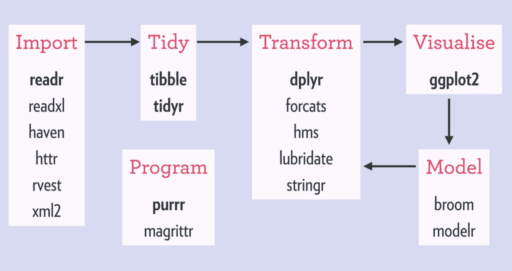

# 6 Using `dplyr` to wrangle data

> Main packages used: `dplyr`  
> Main functions covered: `dplyr::filter()`, `dplyr::select()`, `dplyr::mutate()`, `dplyr::*_join()`, `is.na()`, `tidyr::drop_na()`

> **Supplementary resources:**
> - [Suzan Baert’s blogpost series](https://suzanbaert.netlify.com/2018/01/dplyr-tutorial-1/)
> - [Data Wrangling cheat sheet](https://www.rstudio.com/wp-content/uploads/2015/02/data-wrangling-cheatsheet.pdf)

## 6.1 The pipe

The pipe is this operator: `%>%` You can access with the shortcut of `Ctrl+Shift+M` (or type it out every time, but there are better things in life than that).

What it does, is it passes object on left hand side as first argument (or . argument) of function on righthand side.

As an example:

```r
head(mydata)
# OR
mydata %>% head()
```

Piping together various steps of our data manipulation process greatly increases code readability and our quality of life. In a moment we will see how piping can be super useful.

We will use the gapminder data for demonstrations.

```r
library(dplyr) # for data manipulation
library(ggplot2) # data visualization
library(gapminder) # practice data
```

```r
# load our data
gapminder_df <- gapminder
```

## 6.2 Selecting rows

For subsetting **rows** we use the `filter()` function from `dplyr`. For the argument we can give similar logical operators as before. If we we want to see data for countries in 1962 where life expectancy was above 70 yrs we can do it with the following code:

```r
gapminder_df %>%
    filter(year == 1962, lifeExp > 70)
```

```
#> # A tibble: 16 x 6
#>    country         continent  year lifeExp       pop gdpPercap
#>    <fct>           <fct>     <int>   <dbl>     <int>     <dbl>
#>  1 Australia       Oceania    1962    70.9  10794968    12217.
#>  2 Belgium         Europe     1962    70.2   9218400    10991.
#>  3 Canada          Americas   1962    71.3  18985849    13462.
#>  4 Denmark         Europe     1962    72.4   4646899    13583.
#>  5 France          Europe     1962    70.5  47124000    10560.
#>  6 Germany         Europe     1962    70.3  73739117    12902.
#>  7 Iceland         Europe     1962    73.7    182053    10350.
#>  8 Ireland         Europe     1962    70.3   2830000     6632.
#>  9 Netherlands     Europe     1962    73.2  11805689    12791.
#> 10 New Zealand     Oceania    1962    71.2   2488550    13176.
#> 11 Norway          Europe     1962    73.5   3638919    13450.
#> 12 Slovak Republic Europe     1962    70.3   4237384     7481.
#> 13 Sweden          Europe     1962    73.4   7561588    12329.
#> 14 Switzerland     Europe     1962    71.3   5666000    20431.
#> 15 United Kingdom  Europe     1962    70.8  53292000    12477.
#> 16 United States   Americas   1962    70.2 186538000    16173.
```

You can filter based on logical operators and string matching as well. Here we want to see data for sweden after 1990.

```r
gapminder_df %>%
    filter(country == "Sweden", year > 1990)
```

```
#> # A tibble: 4 x 6
#>   country continent  year lifeExp     pop gdpPercap
#>   <fct>   <fct>     <int>   <dbl>   <int>     <dbl>
#> 1 Sweden  Europe     1992    78.2 8718867    23880.
#> 2 Sweden  Europe     1997    79.4 8897619    25267.
#> 3 Sweden  Europe     2002    80.0 8954175    29342.
#> 4 Sweden  Europe     2007    80.9 9031088    33860.
```

We could also use the `x %in% y` expression which will filter every row where x matches one of the values of y. With this we can filter for two countries in our data.

```r
gapminder_df %>%
    filter(country %in% c("Sweden", "Norway"))
```

```
#> # A tibble: 24 x 6
#>    country continent  year lifeExp     pop gdpPercap
#>    <fct>   <fct>     <int>   <dbl>   <int>     <dbl>
#>  1 Norway  Europe     1952    72.7 3327728    10095.
#>  2 Norway  Europe     1957    73.4 3491938    11654.
#>  3 Norway  Europe     1962    73.5 3638919    13450.
#>  4 Norway  Europe     1967    74.1 3786019    16362.
#>  5 Norway  Europe     1972    74.3 3933004    18965.
#>  6 Norway  Europe     1977    75.4 4043205    23311.
#>  7 Norway  Europe     1982    76.0 4114787    26299.
#>  8 Norway  Europe     1987    75.9 4186147    31541.
#>  9 Norway  Europe     1992    77.3 4286357    33966.
#> 10 Norway  Europe     1997    78.3 4405672    41283.
#> # ... with 14 more rows
```

Filtering on a range can be done with two logical requirement or the `dplyr::between()` argument.

```r
gapminder_df %>%
    filter(lifeExp >= 40, lifeExp <= 40.5)
```

```
#> # A tibble: 16 x 6
#>    country       continent  year lifeExp       pop gdpPercap
#>    <fct>         <fct>     <int>   <dbl>     <int>     <dbl>
#>  1 Benin         Africa     1957    40.4   1925173      960.
#>  2 Bolivia       Americas   1952    40.4   2883315     2677.
#>  3 Cambodia      Asia       1972    40.3   7450606      422.
#>  4 Cameroon      Africa     1957    40.4   5359923     1313.
#>  5 Cote d'Ivoire Africa     1952    40.5   2977019     1389.
#>  6 Eritrea       Africa     1962    40.2   1666618      381.
#>  7 Ethiopia      Africa     1962    40.1  25145372      419.
#>  8 Gabon         Africa     1962    40.5    455661     6631.
#>  9 India         Asia       1957    40.2 409000000      590.
#> 10 Mozambique    Africa     1972    40.3   9809596      725.
#> 11 Niger         Africa     1967    40.1   4534062     1054.
#> 12 Oman          Asia       1957    40.1    561977     2243.
#> 13 Rwanda        Africa     1952    40     2534927      493.
#> 14 Sierra Leone  Africa     1987    40.0   3868905     1294.
#> 15 Vietnam       Asia       1952    40.4  26246839      605.
#> 16 Zambia        Africa     1997    40.2   9417789     1071.
```

They give the same results.

```r
gapminder_df %>%
    filter(between(lifeExp, 40, 40.5))
```

```
#> # A tibble: 16 x 6
#>    country       continent  year lifeExp       pop gdpPercap
#>    <fct>         <fct>     <int>   <dbl>     <int>     <dbl>
#>  1 Benin         Africa     1957    40.4   1925173      960.
#>  2 Bolivia       Americas   1952    40.4   2883315     2677.
#>  3 Cambodia      Asia       1972    40.3   7450606      422.
#>  4 Cameroon      Africa     1957    40.4   5359923     1313.
#>  5 Cote d'Ivoire Africa     1952    40.5   2977019     1389.
#>  6 Eritrea       Africa     1962    40.2   1666618      381.
#>  7 Ethiopia      Africa     1962    40.1  25145372      419.
#>  8 Gabon         Africa     1962    40.5    455661     6631.
#>  9 India         Asia       1957    40.2 409000000      590.
#> 10 Mozambique    Africa     1972    40.3   9809596      725.
#> 11 Niger         Africa     1967    40.1   4534062     1054.
#> 12 Oman          Asia       1957    40.1    561977     2243.
#> 13 Rwanda        Africa     1952    40     2534927      493.
#> 14 Sierra Leone  Africa     1987    40.0   3868905     1294.
#> 15 Vietnam       Asia       1952    40.4  26246839      605.
#> 16 Zambia        Africa     1997    40.2   9417789     1071.
```

We should try out more logical operators to filter. If you are just interested in the top results, you can select rows by their position with the `dplyr::slice()` function.

```r
slice(gapminder_df, 1:8) # select the first 8 rows
```

```
#> # A tibble: 8 x 6
#>   country     continent  year lifeExp      pop gdpPercap
#>   <fct>       <fct>     <int>   <dbl>    <int>     <dbl>
#> 1 Afghanistan Asia       1952    28.8  8425333      779.
#> 2 Afghanistan Asia       1957    30.3  9240934      821.
#> 3 Afghanistan Asia       1962    32.0 10267083      853.
#> 4 Afghanistan Asia       1967    34.0 11537966      836.
#> 5 Afghanistan Asia       1972    36.1 13079460      740.
#> 6 Afghanistan Asia       1977    38.4 14880372      786.
#> 7 Afghanistan Asia       1982    39.9 12881816      978.
#> 8 Afghanistan Asia       1987    40.8 13867957      852.
```

Some exaples of certain logical operators. To see the role of each line, check the comments in the code snippet below.

```r
gapminder_df %>%
    filter(continent == "Africa" & gdpPercap > 8000) # AND
```

```
#> # A tibble: 27 x 6
#>    country           continent  year lifeExp     pop gdpPercap
#>    <fct>             <fct>     <int>   <dbl>   <int>     <dbl>
#>  1 Botswana          Africa     1997    52.6 1536536     8647.
#>  2 Botswana          Africa     2002    46.6 1630347    11004.
#>  3 Botswana          Africa     2007    50.7 1639131    12570.
#>  4 Equatorial Guinea Africa     2007    51.6  551201    12154.
#>  5 Gabon             Africa     1967    44.6  489004     8359.
#>  6 Gabon             Africa     1972    48.7  537977    11402.
#>  7 Gabon             Africa     1977    52.8  706367    21746.
#>  8 Gabon             Africa     1982    56.6  753874    15113.
#>  9 Gabon             Africa     1987    60.2  880397    11864.
#> 10 Gabon             Africa     1992    61.4  985739    13522.
#> # ... with 17 more rows
```

```r
gapminder_df %>%
    filter(!continent %in% c("Africa", "Europe") ) # everything but Africa and Europe (!%in% won't work)
```

```
#> # A tibble: 720 x 6
#>    country     continent  year lifeExp      pop gdpPercap
#>    <fct>       <fct>     <int>   <dbl>    <int>     <dbl>
#>  1 Afghanistan Asia       1952    28.8  8425333      779.
#>  2 Afghanistan Asia       1957    30.3  9240934      821.
#>  3 Afghanistan Asia       1962    32.0 10267083      853.
#>  4 Afghanistan Asia       1967    34.0 11537966      836.
#>  5 Afghanistan Asia       1972    36.1 13079460      740.
#>  6 Afghanistan Asia       1977    38.4 14880372      786.
#>  7 Afghanistan Asia       1982    39.9 12881816      978.
#>  8 Afghanistan Asia       1987    40.8 13867957      852.
#>  9 Afghanistan Asia       1992    41.7 16317921      649.
#> 10 Afghanistan Asia       1997    41.8 22227415      635.
#> # ... with 710 more rows
```

```r
gapminder_df %>%
    filter(year > 1990,  !lifeExp < 80) # we filter for the years after 1990 where the lifeExp < 80 condition is FALSE
```

```
#> # A tibble: 22 x 6
#>    country          continent  year lifeExp      pop gdpPercap
#>    <fct>            <fct>     <int>   <dbl>    <int>     <dbl>
#>  1 Australia        Oceania    2002    80.4 19546792    30688.
#>  2 Australia        Oceania    2007    81.2 20434176    34435.
#>  3 Canada           Americas   2007    80.7 33390141    36319.
#>  4 France           Europe     2007    80.7 61083916    30470.
#>  5 Hong Kong, China Asia       1997    80    6495918    28378.
#>  6 Hong Kong, China Asia       2002    81.5  6762476    30209.
#>  7 Hong Kong, China Asia       2007    82.2  6980412    39725.
#>  8 Iceland          Europe     2002    80.5   288030    31163.
#>  9 Iceland          Europe     2007    81.8   301931    36181.
#> 10 Israel           Asia       2007    80.7  6426679    25523.
#> # ... with 12 more rows
```

## 6.3 Selecting columns and re-ordering values

For selection of **columns (variables)** we will use the, `dplyr::select()` function. The logic is the same as for filtering rows.

```r
gapminder_df %>%
    select(continent)
```

```
#> # A tibble: 1,704 x 1
#>    continent
#>    <fct>
#>  1 Asia
#>  2 Asia
#>  3 Asia
#>  4 Asia
#>  5 Asia
#>  6 Asia
#>  7 Asia
#>  8 Asia
#>  9 Asia
#> 10 Asia
#> # ... with 1,694 more rows
```

you can select multiple columns easily by their name

```r
gapminder_df %>%
    select(continent, year)
```

```
#> # A tibble: 1,704 x 2
#>    continent  year
#>    <fct>     <int>
#>  1 Asia       1952
#>  2 Asia       1957
#>  3 Asia       1962
#>  4 Asia       1967
#>  5 Asia       1972
#>  6 Asia       1977
#>  7 Asia       1982
#>  8 Asia       1987
#>  9 Asia       1992
#> 10 Asia       1997
#> # ... with 1,694 more rows
```

or give a range

```r
gapminder_df %>%
    select(country:year)
```

```
#> # A tibble: 1,704 x 3
#>    country     continent  year
#>    <fct>       <fct>     <int>
#>  1 Afghanistan Asia       1952
#>  2 Afghanistan Asia       1957
#>  3 Afghanistan Asia       1962
#>  4 Afghanistan Asia       1967
#>  5 Afghanistan Asia       1972
#>  6 Afghanistan Asia       1977
#>  7 Afghanistan Asia       1982
#>  8 Afghanistan Asia       1987
#>  9 Afghanistan Asia       1992
#> 10 Afghanistan Asia       1997
#> # ... with 1,694 more rows
```

The select function works if you have a very large dataset and want to access columns by their location rather than their name. Let’s say we want the first two and the fifth variable.

```r
gapminder_df %>%
    select(1:2, 5)
```

```
#> # A tibble: 1,704 x 3
#>    country     continent      pop
#>    <fct>       <fct>        <int>
#>  1 Afghanistan Asia       8425333
#>  2 Afghanistan Asia       9240934
#>  3 Afghanistan Asia      10267083
#>  4 Afghanistan Asia      11537966
#>  5 Afghanistan Asia      13079460
#>  6 Afghanistan Asia      14880372
#>  7 Afghanistan Asia      12881816
#>  8 Afghanistan Asia      13867957
#>  9 Afghanistan Asia      16317921
#> 10 Afghanistan Asia      22227415
#> # ... with 1,694 more rows
```

You can have remove columns with `select(data, -column)`. This code removs columns between year and gdp per capita.

```r
gapminder_df %>%
    select(-(year:gdpPercap))
```

```
#> # A tibble: 1,704 x 2
#>    country     continent
#>    <fct>       <fct>
#>  1 Afghanistan Asia
#>  2 Afghanistan Asia
#>  3 Afghanistan Asia
#>  4 Afghanistan Asia
#>  5 Afghanistan Asia
#>  6 Afghanistan Asia
#>  7 Afghanistan Asia
#>  8 Afghanistan Asia
#>  9 Afghanistan Asia
#> 10 Afghanistan Asia
#> # ... with 1,694 more rows
```

There are various helper functions that you can embed within `select`:

- `starts_with("xyz")`: selects column where the name matches the specified `"xyz"` string.
- `ends_with("jfk")`: matches the string (“jfk” in this case) with the end of the column name
- `contains("klm")`: matches names that contain “klm”
- `num_range("x", 1:3)`: matches x1, x2, x3

The `select()` function also lets us do some other data manipulation tasks as well. You can use it to reorder and rename your variables. The order you specify the columns in the `select()` function will be the new order. You can also set the name with `select(newname = oldname)`, altough it that case it will drop all other columns not specified. To avoid this, you can be explicit about renaming with the `dplyr::rename()` function.

```r
# reorder our variables and rename them.
gapminder_df %>%
    select(country, continent, year, gdpPercap, lifeExp, -pop) %>% # we reorder the columns and drop the pop column
    rename(gdp_percap = gdpPercap, life_exp = lifeExp)
```

```
#> # A tibble: 1,704 x 5
#>    country     continent  year gdp_percap life_exp
#>    <fct>       <fct>     <int>      <dbl>    <dbl>
#>  1 Afghanistan Asia       1952       779.     28.8
#>  2 Afghanistan Asia       1957       821.     30.3
#>  3 Afghanistan Asia       1962       853.     32.0
#>  4 Afghanistan Asia       1967       836.     34.0
#>  5 Afghanistan Asia       1972       740.     36.1
#>  6 Afghanistan Asia       1977       786.     38.4
#>  7 Afghanistan Asia       1982       978.     39.9
#>  8 Afghanistan Asia       1987       852.     40.8
#>  9 Afghanistan Asia       1992       649.     41.7
#> 10 Afghanistan Asia       1997       635.     41.8
#> # ... with 1,694 more rows
```

If you want you can store the column names in a character vector and plug that in to the function.

```r
vars <- c("lifeExp", "pop", "gdpPercap") # columns we want selected
gapminder_df %>%
    select(vars)
```

```
#> # A tibble: 1,704 x 3
#>    lifeExp      pop gdpPercap
#>      <dbl>    <int>     <dbl>
#>  1    28.8  8425333      779.
#>  2    30.3  9240934      821.
#>  3    32.0 10267083      853.
#>  4    34.0 11537966      836.
#>  5    36.1 13079460      740.
#>  6    38.4 14880372      786.
#>  7    39.9 12881816      978.
#>  8    40.8 13867957      852.
#>  9    41.7 16317921      649.
#> 10    41.8 22227415      635.
#> # ... with 1,694 more rows
```

We can also re-order our cases by a given column, either in descending or ascending order. The `dplyr::arrange()` function will re-order in ascending order by default.

```r
# lets pipe together a select and arrange function
gapminder_df %>%
    select(lifeExp) %>%
    arrange(lifeExp)
```

```
#> # A tibble: 1,704 x 1
#>    lifeExp
#>      <dbl>
#>  1    23.6
#>  2    28.8
#>  3    30
#>  4    30.0
#>  5    30.3
#>  6    30.3
#>  7    31.2
#>  8    31.3
#>  9    31.6
#> 10    32.0
#> # ... with 1,694 more rows
```

You can use `dplyr::desc()` within `arrange()` to order the values in descending order.

## 6.4 Recoding and adding variables

`dplyr` makes it easy to recode our columns and create new ones with the `dplyr::mutate()` and `dplyr::transmute()` functions. `mutate()` let’s you do all the stuff that we covered when we looked at vectors. You have the option to have the calculation results in a new column (preferable) or overwrite an existing one (probably not the best idea).

Let’s recode the pop variable to show population by a thousand using the `mutate` function. We will call our new variable pop_k.

```r
gapminder_df %>%
    select(country, year, pop) %>%
    mutate(pop_k = pop/1000) # creating the new column, pop_k
```

```
#> # A tibble: 1,704 x 4
#>    country      year      pop  pop_k
#>    <fct>       <int>    <int>  <dbl>
#>  1 Afghanistan  1952  8425333  8425.
#>  2 Afghanistan  1957  9240934  9241.
#>  3 Afghanistan  1962 10267083 10267.
#>  4 Afghanistan  1967 11537966 11538.
#>  5 Afghanistan  1972 13079460 13079.
#>  6 Afghanistan  1977 14880372 14880.
#>  7 Afghanistan  1982 12881816 12882.
#>  8 Afghanistan  1987 13867957 13868.
#>  9 Afghanistan  1992 16317921 16318.
#> 10 Afghanistan  1997 22227415 22227.
#> # ... with 1,694 more rows
```

We can carry out operations with our existing columns as well. Let’s calculate the GDP from the GDP per capita and population data.

```r
gapminder_df %>%
    select(country, year, gdpPercap) %>%
    mutate(gdp = gdpPercap * pop)
```

[output not shown]

What is the problem? We should be careful about the order we pipe together various functions.

```r
gapminder_df %>%
    mutate(gdp_mil = ((gdpPercap * pop)/10^6)) %>% # multiply the two columns and then divide by a million
    select(country, year, gdp_mil)
```

```
#> # A tibble: 1,704 x 3
#>    country      year gdp_mil
#>    <fct>       <int>   <dbl>
#>  1 Afghanistan  1952   6567.
#>  2 Afghanistan  1957   7585.
#>  3 Afghanistan  1962   8759.
#>  4 Afghanistan  1967   9648.
#>  5 Afghanistan  1972   9679.
#>  6 Afghanistan  1977  11698.
#>  7 Afghanistan  1982  12599.
#>  8 Afghanistan  1987  11821.
#>  9 Afghanistan  1992  10596.
#> 10 Afghanistan  1997  14122.
#> # ... with 1,694 more rows
```

# 7 Exploration by visualization

Using data visualization is a great way to get acquinted with your data and sometimes it makes more sense than looking at large tables. In this section we get into the `ggplot2` package which we’ll use throughout the class. It is the cutting edge of R’s data visualization toolset (not just in academia, but in business and data journalism as well).

### 7.0.1 Introduction to `ggplot2`

The name stands for *grammar of graphics* and it enables you to build your plot layer by layer and having the ability to control every detail of the output (if you so wish). It is used by many in academia, by Uber, StackOverflow, AirBnB, the Financial Times, BBC and FiveThirtyEight writers, among many others.

You create plots with the below syntax:

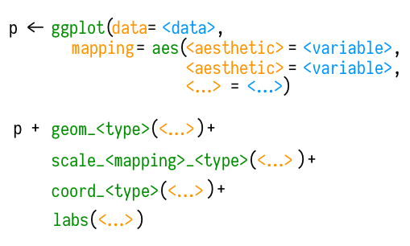

*Source: Kieran, Healy. Data Visualisation: A Practical Introduction. PRINCETON University Press, 2018. [(Ch.3)](http://socviz.co/makeplot.html#how-ggplot-works)*

To have some idea about our variables, lets plot them on a histogram. First, we examine the GDP per capita variable from our gapminder dataset. To this, we just use the `geom_histogram()` function of `ggplot2`. It gives a bare-bones histogram of the (frequency distribution of our choosen continous variable) of the choosen variable.

Let’s create the foundation of our plot by specifying for `ggplot` the data we use and the variable we want to plot.

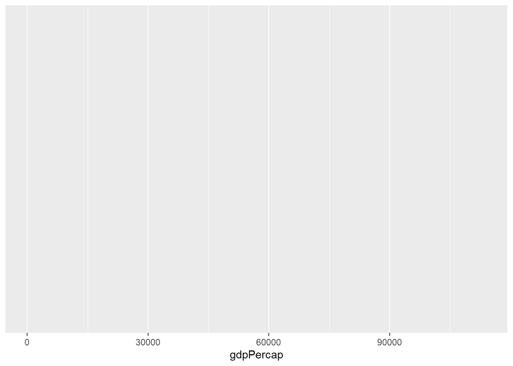

```r
ggplot(data = gapminder_df,
       mapping = aes(x = gdpPercap))
```

We need to specify what sort of shape we want our data to be displayed. We can do this by adding the `geom_histogram()` function with a `+`

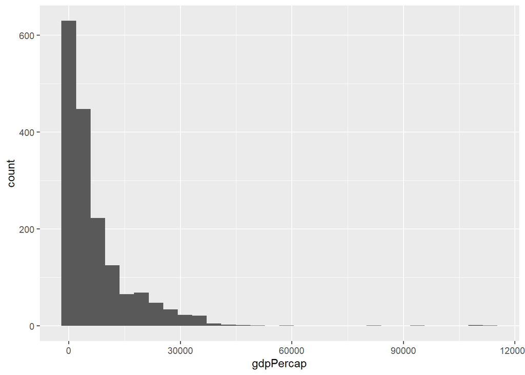

```r
ggplot(data = gapminder_df,
       mapping = aes(x = gdpPercap)) +
  geom_histogram()
```

Looks a little bit skewed. Let’s log transform our variable with the `scale_x_log10()` function.

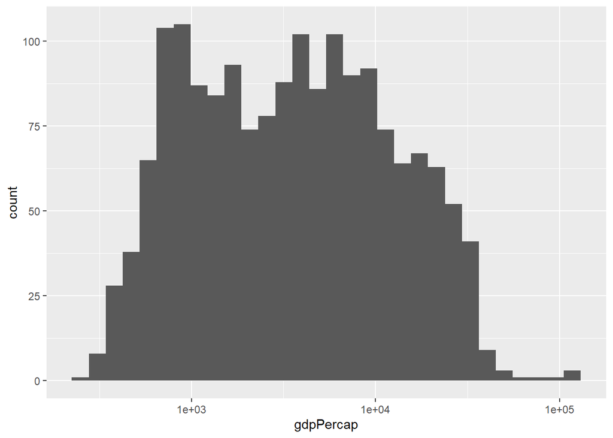

```r
ggplot(data = gapminder_df,
       mapping = aes(x = gdpPercap)) +
  geom_histogram() +
  scale_x_log10()
```

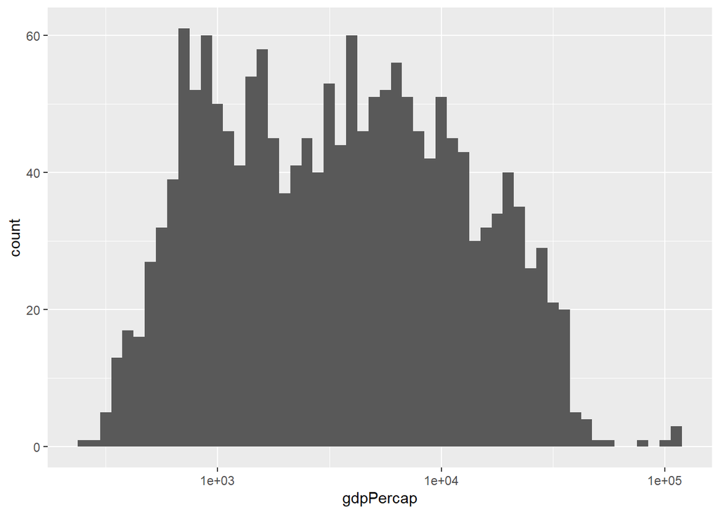

```r
ggplot(data = gapminder_df,
       mapping = aes(x = gdpPercap)) +
  geom_histogram(binwidth = 0.05) +
  scale_x_log10()
```

Of course if one prefers a boxplot, that is possible as well. We will check how life expectancy varies between and within continents. We’ll use `geom_boxplot()`. In this approach, we create an object for our plot. You don’t need to do this (there are instances where it is useful), but this shows you that just about everything can be an object in R

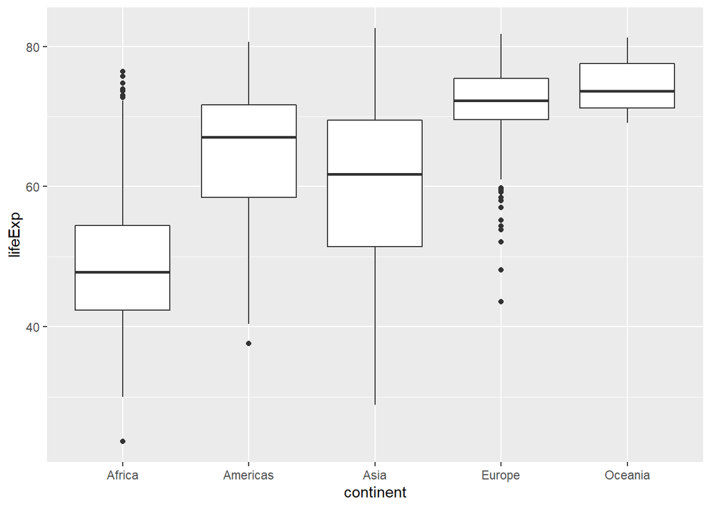

```r
p_box <- ggplot(data = gapminder_df,
                mapping = aes(x = continent,
                              y = lifeExp)) +
  geom_boxplot()
p_box
```